# NFL PLAY PREDICTOR

## A statistical model designed to predict whether a given down will be a designed run, pass, punt, or field goal based on all games played during the 2009 - 2018 NFL seasons

#### Using dataset "NFL Play by Play 2009-2018 (v5).csv" from https://www.kaggle.com/maxhorowitz/nflplaybyplay2009to2016?select=NFL+Play+by+Play+2009-2018+%28v5%29.csv

#### Given that the data set has 255 data points on every play run between 2009 - 2018 and is 667 MB, I decided to trim it down in excel to the the twenty variables I thought might be the most relevant, to be experimented on before I decide on my final feature variables. I chose this data set because it has the most data points to choose from on every play run in the last decade in the NFL. My hypothesis is that it won't be possible to predict plays above roughly 75%-80% of the time, because offenses in the NFL intentionally mix it up. I believe it will be easier to predict field goals and punts than runs vs passes.

```python
# Importing libraries
import pandas as pd
import numpy as np
```

```python
# Reading the data set into a pandas data frame
df = pd.read_csv('NFL Play by Play 2009-2018 (v5).csv')
df.head()
```

|  | posteam | defteam | yardline_100 | game_date | half_seconds_remaining | game_half | qtr | down | goal_to_go | time | ydstogo | ydsnet | play_type | no_huddle | timeout | posteam_timeouts_remaining | defteam_timeouts_remaining | posteam_score | defteam_score | score_differential |
| --- | --- | --- | --- | --- | --- | --- | --- | --- | --- | --- | --- | --- | --- | --- | --- | --- | --- | --- | --- | --- |
| 0 | PIT | TEN | 30.0 | 9/10/2009 | 1800.0 | Half1 | 1 | NaN | 0.0 | 15:00 | 0 | 0 | kickoff | 0 | 0.0 | 3.0 | 3.0 | NaN | NaN | NaN |
| 1 | PIT | TEN | 58.0 | 9/10/2009 | 1793.0 | Half1 | 1 | 1.0 | 0.0 | 14:53 | 10 | 5 | pass | 0 | 0.0 | 3.0 | 3.0 | 0.0 | 0.0 | 0.0 |
| 2 | PIT | TEN | 53.0 | 9/10/2009 | 1756.0 | Half1 | 1 | 2.0 | 0.0 | 14:16 | 5 | 2 | run | 0 | 0.0 | 3.0 | 3.0 | 0.0 | 0.0 | 0.0 |
| 3 | PIT | TEN | 56.0 | 9/10/2009 | 1715.0 | Half1 | 1 | 3.0 | 0.0 | 13:35 | 8 | 2 | pass | 0 | 0.0 | 3.0 | 3.0 | 0.0 | 0.0 | 0.0 |
| 4 | PIT | TEN | 56.0 | 9/10/2009 | 1707.0 | Half1 | 1 | 4.0 | 0.0 | 13:27 | 8 | 2 | punt | 0 | 0.0 | 3.0 | 3.0 | 0.0 | 0.0 | 0.0 |

## Cleaning the data set

```python
# Remove all kickoffs, extra point attempts, penalties, and time-outs
df.play_type.unique()
```

```
array(['kickoff', 'pass', 'run', 'punt', 'field_goal', 'no_play', nan,
       'extra_point', 'qb_kneel', 'qb_spike'], dtype=object)
```

```python
# Remove all kickoffs, extra point attempts, penalties, qb kneels, spikes, and time-outs (continued)
df = df[df.play_type != 'kickoff'][df.play_type != 'no_play'][df.play_type != 'extra_point'][df.play_type != 'qb_kneel'][df.play_type != 'qb_spike'].dropna()
df.play_type.unique()
```

```
array(['pass', 'run', 'punt', 'field_goal'], dtype=object)
```

```python
# Assign the year to each team so that each year each team is treated as its own entity with its own tendencies
df['game_date'] = df['game_date'].str[-4:]
df['posteam'] = df['posteam'] + df['game_date']
df['defteam'] = df['defteam'] + df['game_date']
df = df.drop(['game_date'], axis=1)
df.head()
```

|  | posteam | defteam | yardline_100 | half_seconds_remaining | game_half | qtr | down | goal_to_go | time | ydstogo | ydsnet | play_type | no_huddle | timeout | posteam_timeouts_remaining | defteam_timeouts_remaining | posteam_score | defteam_score | score_differential |
| --- | --- | --- | --- | --- | --- | --- | --- | --- | --- | --- | --- | --- | --- | --- | --- | --- | --- | --- | --- |
| 1 | PIT2009 | TEN2009 | 58.0 | 1793.0 | Half1 | 1 | 1.0 | 0.0 | 14:53 | 10 | 5 | pass | 0 | 0.0 | 3.0 | 3.0 | 0.0 | 0.0 | 0.0 |
| 2 | PIT2009 | TEN2009 | 53.0 | 1756.0 | Half1 | 1 | 2.0 | 0.0 | 14:16 | 5 | 2 | run | 0 | 0.0 | 3.0 | 3.0 | 0.0 | 0.0 | 0.0 |
| 3 | PIT2009 | TEN2009 | 56.0 | 1715.0 | Half1 | 1 | 3.0 | 0.0 | 13:35 | 8 | 2 | pass | 0 | 0.0 | 3.0 | 3.0 | 0.0 | 0.0 | 0.0 |
| 4 | PIT2009 | TEN2009 | 56.0 | 1707.0 | Half1 | 1 | 4.0 | 0.0 | 13:27 | 8 | 2 | punt | 0 | 0.0 | 3.0 | 3.0 | 0.0 | 0.0 | 0.0 |
| 5 | TEN2009 | PIT2009 | 98.0 | 1696.0 | Half1 | 1 | 1.0 | 0.0 | 13:16 | 10 | 0 | run | 0 | 0.0 | 3.0 | 3.0 | 0.0 | 0.0 | 0.0 |

```python
# Make useful datapoints for game situation
df['last_play_of_half'] = df['half_seconds_remaining'] < 10
df['two_minute_drill'] = df['half_seconds_remaining'] < 180
df['fourth_quarter'] = ((df['game_half'] == 'Half2') & (df['half_seconds_remaining'] < 900))
df['offense_winning'] = df['score_differential'] > 0
df['two_score_game'] = np.absolute(df['score_differential']) > 8
df['within_three'] = np.absolute(df['score_differential']) < 4
df['field_goal_range'] = df['yardline_100'] < 45
df
```

|  | posteam | defteam | yardline_100 | half_seconds_remaining | game_half | qtr | down | goal_to_go | time | ydstogo | ... | posteam_score | defteam_score | score_differential | last_play_of_half | two_minute_drill | fourth_quarter | offense_winning | two_score_game | within_three | field_goal_range |
| --- | --- | --- | --- | --- | --- | --- | --- | --- | --- | --- | --- | --- | --- | --- | --- | --- | --- | --- | --- | --- | --- |
| 1 | PIT2009 | TEN2009 | 58.0 | 1793.0 | Half1 | 1 | 1.0 | 0.0 | 14:53 | 10 | ... | 0.0 | 0.0 | 0.0 | False | False | False | False | False | True | False |
| 2 | PIT2009 | TEN2009 | 53.0 | 1756.0 | Half1 | 1 | 2.0 | 0.0 | 14:16 | 5 | ... | 0.0 | 0.0 | 0.0 | False | False | False | False | False | True | False |
| 3 | PIT2009 | TEN2009 | 56.0 | 1715.0 | Half1 | 1 | 3.0 | 0.0 | 13:35 | 8 | ... | 0.0 | 0.0 | 0.0 | False | False | False | False | False | True | False |
| 4 | PIT2009 | TEN2009 | 56.0 | 1707.0 | Half1 | 1 | 4.0 | 0.0 | 13:27 | 8 | ... | 0.0 | 0.0 | 0.0 | False | False | False | False | False | True | False |
| 5 | TEN2009 | PIT2009 | 98.0 | 1696.0 | Half1 | 1 | 1.0 | 0.0 | 13:16 | 10 | ... | 0.0 | 0.0 | 0.0 | False | False | False | False | False | True | False |
| ... | ... | ... | ... | ... | ... | ... | ... | ... | ... | ... | ... | ... | ... | ... | ... | ... | ... | ... | ... | ... | ... |
| 449363 | CAR2018 | NO2018 | 71.0 | 82.0 | Half2 | 4 | 2.0 | 0.0 | 1:22:00 | 1 | ... | 7.0 | 12.0 | -5.0 | False | True | True | False | False | False | False |
| 449364 | CAR2018 | NO2018 | 71.0 | 77.0 | Half2 | 4 | 3.0 | 0.0 | 1:17:00 | 1 | ... | 7.0 | 12.0 | -5.0 | False | True | True | False | False | False | False |
| 449366 | CAR2018 | NO2018 | 66.0 | 63.0 | Half2 | 4 | 2.0 | 0.0 | 1:03:00 | 10 | ... | 7.0 | 12.0 | -5.0 | False | True | True | False | False | False | False |
| 449367 | CAR2018 | NO2018 | 66.0 | 58.0 | Half2 | 4 | 3.0 | 0.0 | 0:58:00 | 10 | ... | 7.0 | 12.0 | -5.0 | False | True | True | False | False | False | False |
| 449368 | CAR2018 | NO2018 | 61.0 | 38.0 | Half2 | 4 | 4.0 | 0.0 | 0:38:00 | 5 | ... | 7.0 | 12.0 | -5.0 | False | True | True | False | False | False | False |

352362 rows × 26 columns

```python
# Drop remaining data points I'm not going to use
df = df.drop(['half_seconds_remaining','game_half','qtr','time','posteam_score','defteam_score','score_differential','defteam_timeouts_remaining','timeout','ydsnet'], axis=1)
df
```

|  | posteam | defteam | yardline_100 | down | goal_to_go | ydstogo | play_type | no_huddle | posteam_timeouts_remaining | last_play_of_half | two_minute_drill | fourth_quarter | offense_winning | two_score_game | within_three | field_goal_range |
| --- | --- | --- | --- | --- | --- | --- | --- | --- | --- | --- | --- | --- | --- | --- | --- | --- |
| 1 | PIT2009 | TEN2009 | 58.0 | 1.0 | 0.0 | 10 | pass | 0 | 3.0 | False | False | False | False | False | True | False |
| 2 | PIT2009 | TEN2009 | 53.0 | 2.0 | 0.0 | 5 | run | 0 | 3.0 | False | False | False | False | False | True | False |
| 3 | PIT2009 | TEN2009 | 56.0 | 3.0 | 0.0 | 8 | pass | 0 | 3.0 | False | False | False | False | False | True | False |
| 4 | PIT2009 | TEN2009 | 56.0 | 4.0 | 0.0 | 8 | punt | 0 | 3.0 | False | False | False | False | False | True | False |
| 5 | TEN2009 | PIT2009 | 98.0 | 1.0 | 0.0 | 10 | run | 0 | 3.0 | False | False | False | False | False | True | False |
| ... | ... | ... | ... | ... | ... | ... | ... | ... | ... | ... | ... | ... | ... | ... | ... | ... |
| 449363 | CAR2018 | NO2018 | 71.0 | 2.0 | 0.0 | 1 | pass | 1 | 0.0 | False | True | True | False | False | False | False |
| 449364 | CAR2018 | NO2018 | 71.0 | 3.0 | 0.0 | 1 | pass | 0 | 0.0 | False | True | True | False | False | False | False |
| 449366 | CAR2018 | NO2018 | 66.0 | 2.0 | 0.0 | 10 | pass | 0 | 0.0 | False | True | True | False | False | False | False |
| 449367 | CAR2018 | NO2018 | 66.0 | 3.0 | 0.0 | 10 | pass | 0 | 0.0 | False | True | True | False | False | False | False |
| 449368 | CAR2018 | NO2018 | 61.0 | 4.0 | 0.0 | 5 | pass | 1 | 0.0 | False | True | True | False | False | False | False |

352362 rows × 16 columns

```python
# Map true and false values to ones and zeros and set the index to play_type
df.loc[:,'last_play_of_half':] = df.loc[:,'last_play_of_half':].astype(int)
df
```

|  | posteam | defteam | yardline_100 | down | goal_to_go | ydstogo | play_type | no_huddle | posteam_timeouts_remaining | last_play_of_half | two_minute_drill | fourth_quarter | offense_winning | two_score_game | within_three | field_goal_range |
| --- | --- | --- | --- | --- | --- | --- | --- | --- | --- | --- | --- | --- | --- | --- | --- | --- |
| 1 | PIT2009 | TEN2009 | 58.0 | 1.0 | 0.0 | 10 | pass | 0 | 3.0 | 0 | 0 | 0 | 0 | 0 | 1 | 0 |
| 2 | PIT2009 | TEN2009 | 53.0 | 2.0 | 0.0 | 5 | run | 0 | 3.0 | 0 | 0 | 0 | 0 | 0 | 1 | 0 |
| 3 | PIT2009 | TEN2009 | 56.0 | 3.0 | 0.0 | 8 | pass | 0 | 3.0 | 0 | 0 | 0 | 0 | 0 | 1 | 0 |
| 4 | PIT2009 | TEN2009 | 56.0 | 4.0 | 0.0 | 8 | punt | 0 | 3.0 | 0 | 0 | 0 | 0 | 0 | 1 | 0 |
| 5 | TEN2009 | PIT2009 | 98.0 | 1.0 | 0.0 | 10 | run | 0 | 3.0 | 0 | 0 | 0 | 0 | 0 | 1 | 0 |
| ... | ... | ... | ... | ... | ... | ... | ... | ... | ... | ... | ... | ... | ... | ... | ... | ... |
| 449363 | CAR2018 | NO2018 | 71.0 | 2.0 | 0.0 | 1 | pass | 1 | 0.0 | 0 | 1 | 1 | 0 | 0 | 0 | 0 |
| 449364 | CAR2018 | NO2018 | 71.0 | 3.0 | 0.0 | 1 | pass | 0 | 0.0 | 0 | 1 | 1 | 0 | 0 | 0 | 0 |
| 449366 | CAR2018 | NO2018 | 66.0 | 2.0 | 0.0 | 10 | pass | 0 | 0.0 | 0 | 1 | 1 | 0 | 0 | 0 | 0 |
| 449367 | CAR2018 | NO2018 | 66.0 | 3.0 | 0.0 | 10 | pass | 0 | 0.0 | 0 | 1 | 1 | 0 | 0 | 0 | 0 |
| 449368 | CAR2018 | NO2018 | 61.0 | 4.0 | 0.0 | 5 | pass | 1 | 0.0 | 0 | 1 | 1 | 0 | 0 | 0 | 0 |

352362 rows × 16 columns

## Data Analysis

```python
df2 = df
df2.describe(include='all')
```

|  | posteam | defteam | yardline_100 | down | goal_to_go | ydstogo | play_type | no_huddle | posteam_timeouts_remaining | last_play_of_half | two_minute_drill | fourth_quarter | offense_winning | two_score_game | within_three | field_goal_range |
| --- | --- | --- | --- | --- | --- | --- | --- | --- | --- | --- | --- | --- | --- | --- | --- | --- |
| count | 352362 | 352362 | 352362.000000 | 352362.000000 | 352362.000000 | 352362.000000 | 352362 | 352362.000000 | 352362.000000 | 352362.000000 | 352362.000000 | 352362.000000 | 352362.000000 | 352362.000000 | 352362.000000 | 352362.000000 |
| unique | 323 | 323 | NaN | NaN | NaN | NaN | 4 | NaN | NaN | NaN | NaN | NaN | NaN | NaN | NaN | NaN |
| top | DET2012 | BAL2012 | NaN | NaN | NaN | NaN | pass | NaN | NaN | NaN | NaN | NaN | NaN | NaN | NaN | NaN |
| freq | 1341 | 1276 | NaN | NaN | NaN | NaN | 186166 | NaN | NaN | NaN | NaN | NaN | NaN | NaN | NaN | NaN |
| mean | NaN | NaN | 52.511531 | 2.002395 | 0.056655 | 8.594491 | NaN | 0.079064 | 2.555664 | 0.006786 | 0.147593 | 0.256529 | 0.348786 | 0.350049 | 0.361475 | 0.357612 |
| std | NaN | NaN | 24.625480 | 1.009090 | 0.231182 | 4.122083 | NaN | 0.269838 | 0.749886 | 0.082095 | 0.354696 | 0.436718 | 0.476587 | 0.476986 | 0.480428 | 0.479298 |
| min | NaN | NaN | 1.000000 | 1.000000 | 0.000000 | 1.000000 | NaN | 0.000000 | 0.000000 | 0.000000 | 0.000000 | 0.000000 | 0.000000 | 0.000000 | 0.000000 | 0.000000 |
| 25% | NaN | NaN | 34.000000 | 1.000000 | 0.000000 | 6.000000 | NaN | 0.000000 | 2.000000 | 0.000000 | 0.000000 | 0.000000 | 0.000000 | 0.000000 | 0.000000 | 0.000000 |
| 50% | NaN | NaN | 56.000000 | 2.000000 | 0.000000 | 10.000000 | NaN | 0.000000 | 3.000000 | 0.000000 | 0.000000 | 0.000000 | 0.000000 | 0.000000 | 0.000000 | 0.000000 |
| 75% | NaN | NaN | 73.000000 | 3.000000 | 0.000000 | 10.000000 | NaN | 0.000000 | 3.000000 | 0.000000 | 0.000000 | 1.000000 | 1.000000 | 1.000000 | 1.000000 | 1.000000 |
| max | NaN | NaN | 99.000000 | 4.000000 | 1.000000 | 50.000000 | NaN | 1.000000 | 3.000000 | 1.000000 | 1.000000 | 1.000000 | 1.000000 | 1.000000 | 1.000000 | 1.000000 |

```python
# Evidence for why it was important to add situational binary variables
df2.where(df2['down'] == 4)[['play_type']].mode()
```

|  | play_type |
| --- | --- |
| 0 | punt |

#### This is a perfect example of why I chose to add so many situational binary variables. Being within field goal range is a great indicator of whether or not a team is going to attempt a field goal.

```python
df2.where((df2['down'] == 4) & (df2['field_goal_range'] == 1))[['play_type']].mode()
```

|  | play_type |
| --- | --- |
| 0 | field_goal |

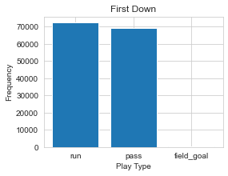

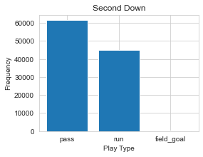

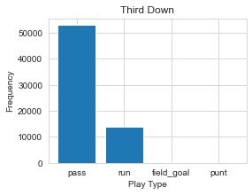

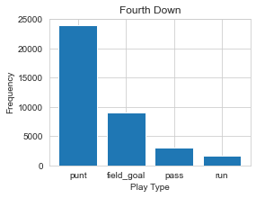

```python
import matplotlib.pyplot as plt
%matplotlib inline
plt.rcParams['figure.figsize'] = (4.0, 3.0) #setting figure size
#plot play type count by down
plt.bar(df2.where(df2['down']==1)['play_type'].value_counts().index, df2.where(df2['down']==1)['play_type'].value_counts().values)
plt.xlabel("Play Type")
plt.ylabel("Frequency")
plt.title("First Down")
plt.show()
plt.bar(df2.where(df2['down']==2)['play_type'].value_counts().index, df2.where(df2['down']==2)['play_type'].value_counts().values)
plt.xlabel("Play Type")
plt.ylabel("Frequency")
plt.title("Second Down")
plt.show()
plt.bar(df2.where(df2['down']==3)['play_type'].value_counts().index, df2.where(df2['down']==3)['play_type'].value_counts().values)
plt.xlabel("Play Type")
plt.ylabel("Frequency")
plt.title("Third Down")
plt.show()
plt.bar(df2.where(df2['down']==4)['play_type'].value_counts().index, df2.where(df2['down']==4)['play_type'].value_counts().values)
plt.xlabel("Play Type")
plt.ylabel("Frequency")
plt.title("Fourth Down")
plt.show()
```

#### There appears to be a very strong relationship between play type and down. I'm especially surprised by how common a pass is on third down as opposed to a run, without even considering yards to go.

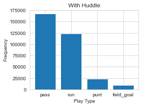

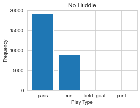

```python
# Plot the play type by no huddle and by huddle to check for any kind of correlation
plt.bar(df2.where(df2['no_huddle']==0)['play_type'].value_counts().index, df2.where(df2['no_huddle']==0)['play_type'].value_counts().values)
plt.xlabel("Play Type")
plt.ylabel("Frequency")
plt.title("With Huddle")
plt.show()
plt.bar(df2.where(df2['no_huddle']==1)['play_type'].value_counts().index, df2.where(df2['no_huddle']==1)['play_type'].value_counts().values)
plt.xlabel("Play Type")
plt.ylabel("Frequency")
plt.title("No Huddle")
plt.show()
```

#### I was ready to delete the no huddle column, but it appears I should keep it, as teams are more likely to pass while running the no huddle.

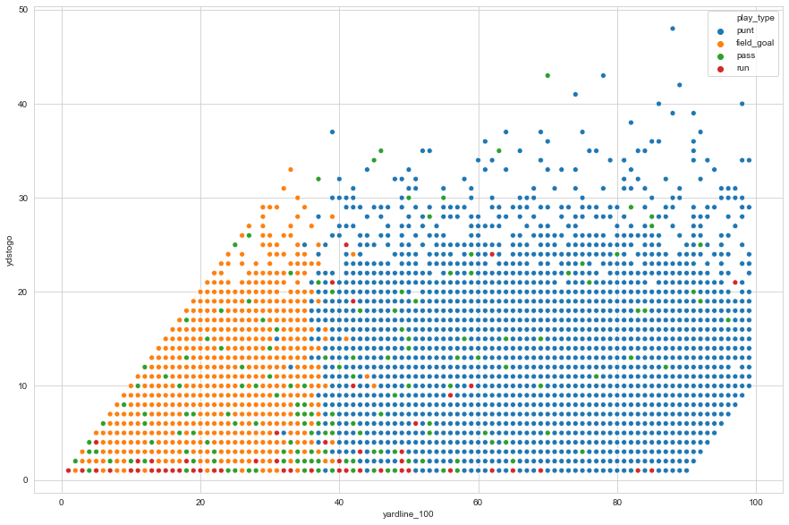

```python
import seaborn as sns
%matplotlib inline

# Plot play type by yard line and yards to go
sns.set_style('whitegrid')
plt.figure(figsize = (15,10))
sns.scatterplot(data=df2.where(df2['down']==4), x='yardline_100', y='ydstogo', hue='play_type')
```

#### A few things can be interpreted from this graph. Teams are more likely to attempt a field goal as they get closer to the endzone on fourth down. Teams are more likely to run when the yards to go is shorter on fourth down and more likely to pass when yards to go is higher. Teams are more and more likely to punt as they get farther from a first down and farther from the end zone on fourth down.

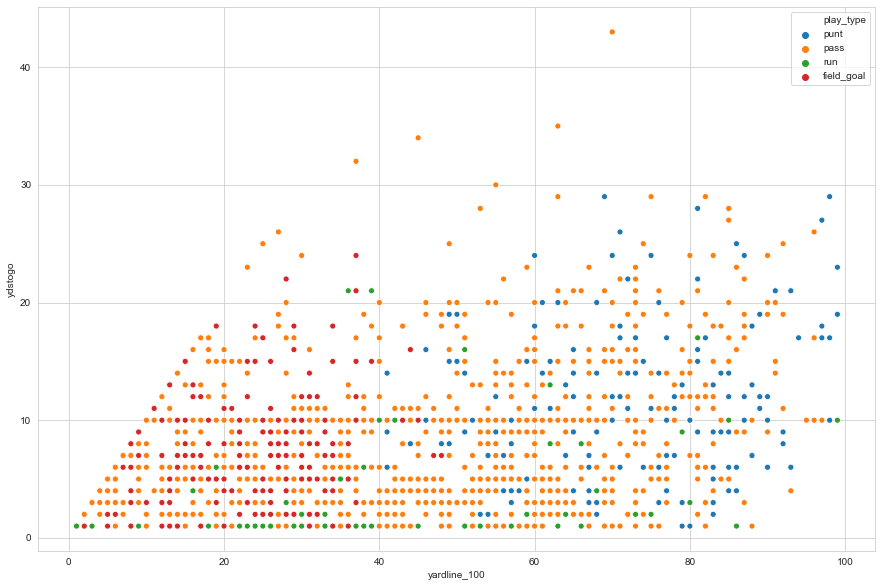

```python
# Plot play type by yard line and yards to go in a desperate situation
plt.figure(figsize = (15,10))
sns.scatterplot(data=df2.where((df2['down']==4)&(df2['two_minute_drill']==1)&(df2['offense_winning']==0)&(df2['fourth_quarter']==1)), x='yardline_100', y='ydstogo', hue='play_type')
```

#### This graph represents a teams tendency to go for it on fourth down with a pass or run, when trailing late in the fourth quarter. This is another example for why it was important to add the special situation variables.

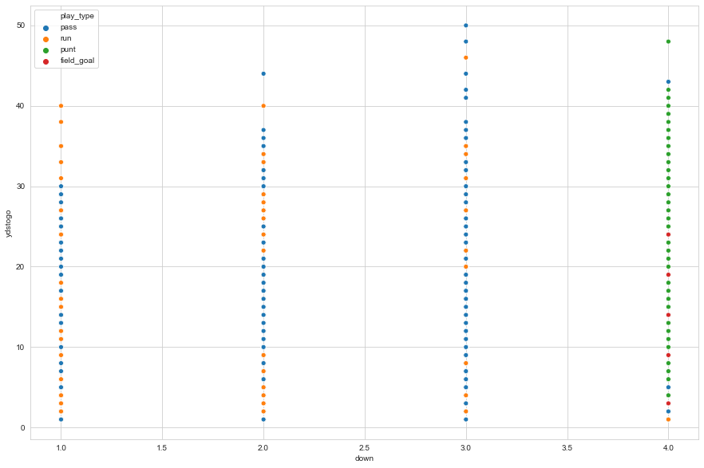

```python
# Plot play type by down and yards to go
plt.figure(figsize = (15,10))
sns.scatterplot(data=df2, x='down', y='ydstogo', hue='play_type')
```

#### This graph displays play selection vs down and yards to go, which I believed would be the easiest way to predict the next play, but it appears the relationship isn't as strong as I had expected

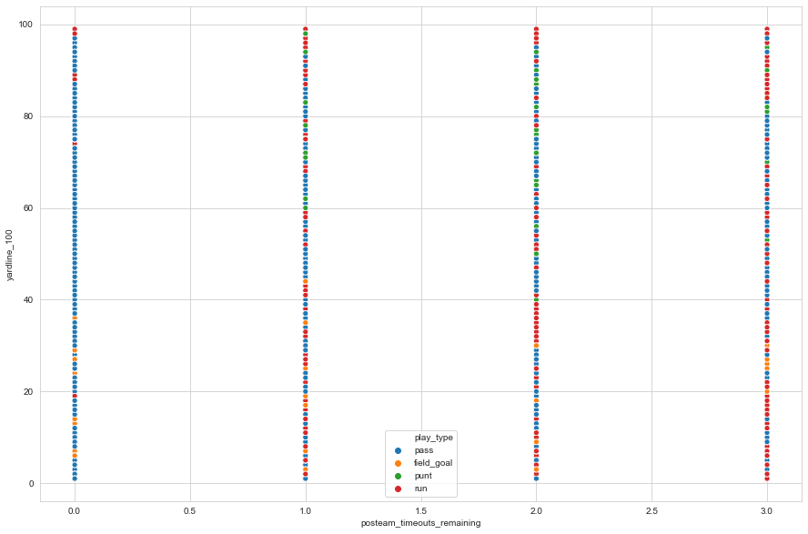

```python
# Plot play type by time_outs_left and field position
plt.figure(figsize = (15,10))
sns.scatterplot(data=df2.where(df2['two_minute_drill']==1), x='posteam_timeouts_remaining', y='yardline_100', hue='play_type')
```

#### This graph proves its worth keeping the timeouts variable for the team with posession

## Numerical Models

### K-Nearest Neighbors

```python
from sklearn.neighbors import KNeighborsClassifier
from sklearn.metrics import accuracy_score
from sklearn.metrics import classification_report
from sklearn.metrics import confusion_matrix
from sklearn.model_selection import train_test_split
```

```python
# Feature vars
X = df2[['yardline_100','down','goal_to_go','ydstogo','no_huddle','last_play_of_half','posteam_timeouts_remaining','two_minute_drill','fourth_quarter','offense_winning','two_score_game','within_three','field_goal_range']]
Y = df2['play_type']
XTrain, XTest, YTrain, YTest = train_test_split(X, Y, test_size = 0.2, random_state = 1)
```

```python
neigh = KNeighborsClassifier(n_neighbors=10)
neigh.fit(XTrain, YTrain)
```

```
KNeighborsClassifier(n_neighbors=10)
```

```python
predictions = neigh.predict(XTest)
```

```python
accuracy_score(YTest, predictions)
```

```
0.6751805656066863
```

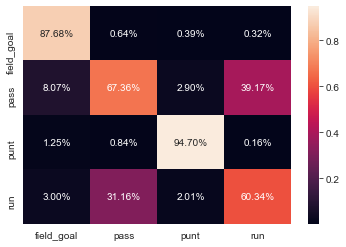

```python
cfm = confusion_matrix(YTest, predictions)
cfm = pd.DataFrame(cfm)
cfm.columns = ['field_goal','pass','punt','run']
cfm.index = ['field_goal','pass','punt','run']
sns.heatmap(cfm/np.sum(cfm), annot=True, fmt='.2%')
```

```python
print(classification_report(YTest, predictions))
```

```
              precision    recall  f1-score   support

  field_goal       0.88      0.82      0.85      1969
        pass       0.67      0.77      0.72     37344
        punt       0.95      0.91      0.93      4756
         run       0.60      0.49      0.54     26404

    accuracy                           0.68     70473
   macro avg       0.78      0.75      0.76     70473
weighted avg       0.67      0.68      0.67     70473
```

```python
#Experimenting with the features and raising the n_neighbors value
X = df2[['yardline_100','down','ydstogo','two_minute_drill','no_huddle','offense_winning','two_score_game','posteam_timeouts_remaining','within_three','field_goal_range']]
Y = df2['play_type']
XTrain, XTest, YTrain, YTest = train_test_split(X, Y, test_size = 0.2, random_state = 1)
neigh = KNeighborsClassifier(n_neighbors=30)
neigh.fit(XTrain, YTrain)
predictions = neigh.predict(XTest)
print(accuracy_score(YTest, predictions))
print(confusion_matrix(YTest, predictions))
print(classification_report(YTest, predictions))
```

```
0.6786286946773942
[[ 1538   344    17    70]
 [  157 27369   149  9669]
 [    8   320  4393    35]
 [   48 11740    91 14525]]
              precision    recall  f1-score   support

  field_goal       0.88      0.78      0.83      1969
        pass       0.69      0.73      0.71     37344
        punt       0.94      0.92      0.93      4756
         run       0.60      0.55      0.57     26404

    accuracy                           0.68     70473
   macro avg       0.78      0.75      0.76     70473
weighted avg       0.68      0.68      0.68     70473
```

#### After messing around with many different combinations of feature variables and n_neighbors values, I've concluded that KNN is not the way to go

### Decision Tree

```python
from sklearn import tree
```

```python
# After experimenting with the feature variables, I decided to drop the posteam and defteam columns
X = df2.drop(['play_type','posteam','defteam'], axis = 1)
Y = df2['play_type']
XTrain, XTest, YTrain, YTest = train_test_split(X, Y, test_size = 0.2, random_state = 1)
```

```python
DecisionTree = tree.DecisionTreeClassifier()
Tree = DecisionTree.fit(X,Y)
```

```python
predictions = Tree.predict(XTest)
```

```python
print(accuracy_score(YTest, predictions))
```

```
0.7810225192626964
```

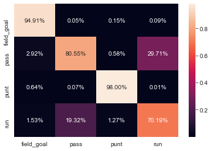

```python
cfm = confusion_matrix(YTest, predictions)
cfm = pd.DataFrame(cfm)
cfm.columns = ['field_goal','pass','punt','run']
cfm.index = ['field_goal','pass','punt','run']
sns.heatmap(cfm/np.sum(cfm), annot=True, fmt='.2%')
```

```python
print(classification_report(YTest, predictions))
```

```
              precision    recall  f1-score   support

  field_goal       0.95      0.98      0.96      1969
        pass       0.81      0.78      0.79     37344
        punt       0.98      0.99      0.99      4756
         run       0.70      0.73      0.72     26404

    accuracy                           0.78     70473
   macro avg       0.86      0.87      0.86     70473
weighted avg       0.78      0.78      0.78     70473
```

## Insights

#### Due to coaches intentionally adding randomness to their play type selection in order to keep the defense on its toes, I began this project knowing it wouldn't be possible to predict play type perfectly. My first thought was to use the KNN algorithm in order to predict the next play call. This method wasn't a total failure, but was a little disapointing, as even after experimenting with many different combinations of feature variables, and number of neighbors, I couldn't get the accuracy above 70%, which isn't great considering predicting punts and field goals should be fairly easy. Just by watching a game, an average fan should be able to predict run and pass plays roughly as well as the KNN algorithm performed. I believe that this is because football is so situational, and in different times of the game, different variables carry more or less weight. For example, being within field goal range doesn't matter if you're down by more than three with less than a few minutes left. This is why a decision tree felt like a better fit. It performed better than the KNN algorithm across the board. I was especially impressed by the model's near perfect f1-score on predicting punts and field goals, as coaches have the option to punt, go for it, or kick a field goal on fourth. I believe the situational nature of the game, and the situational feature variables I added to the data set are the reason the decision tree performed better than I expected.